# HW 2: разедовательный анализ данных 2

Щудро Виктория, vischudro_1

## Задача

Компания заинтересована как в привлечении новых клиентов: так и в удержании уже существующих клиентов. Для этого ей необходимо хорошо понимать свою целевую аудиторию: их предпочтения, факторы, влияющие на спрос, типичную продуктовую корзину и ожидания. Собранные данные позволяют ответить на ряд вопросов, способных прояснить структуру и характеристики целевой аудитории компании. Требуется понять, во-первых, наличие так называемых “постоянных клиентов” и шанс их возникновения посредством анализа отклика на предыдущие кампании, а также экономические факторы изменения спроса, такие как доход и богатство отдельных домохозяйств.

```r
marketing = read.csv("~/shared/minor2_2023/1-Intro/hw2/marketing_campaign.csv")
```

```r
# преобразование данных, предобработка
# вы можете добавлять столько чанков с кодом, сколько вам необходимо, разделяя их текстом с пояснениями
```

### Исследовательские вопросы и тесты

Итак, в соответствие с поставленными задачами было принято решение провести следующее исследование: во-первых, первым исследовательским вопросом будет поставлено выявление взаимосвязи между поведением клиентов в прошлом и их действиями в новую кампанию. Это необходимо для выяснения вероятности возвращения клиента после первого отклика на кампанию. Вторым исследовательским вопросом будет исследование взаимосвязи богатства клиентов и их степенью удовлетворенности сервисом. Также будет построено дерево решений с учетом статистически значимых параметров для прогнозирования клиентского отклика на кампанию.

**Вопрос 1: В данных есть информация, откликнулся ли клиент на предыдущую кампанию. Правда ли, что пользователи, откликнувшиеся на предыдущую кампанию, чаще откликаются и дальше?**

Для того, чтобы понять, насколько связано предыдущее поведение клиента с его текущими решениями нам необходимо найти взаимосвязь между переменными AcceptedCmp и Response. Поскольку обе переменные категориальные, нам необходимо использовать статистический тест хи-квадрат.

```r
# код для ответа на вопрос
# вы можете добавлять столько чанков с кодом, сколько вам необходимо, разделяя их текстом с пояснениями
library(ggplot2)
library(dplyr)
library(coin)
library(ggplot2)
library(gridExtra)
marketing_clear = marketing[complete.cases(marketing$AcceptedCmp), ]
marketing_clear$AcceptedCmp = as.factor(marketing_clear$AcceptedCmp)
marketing_clear$Response = as.factor(marketing_clear$Response)
chi <- chisq.test(marketing_clear$AcceptedCmp, marketing_clear$Response)
independence_test(marketing_clear$AcceptedCmp ~ marketing_clear$Response, data = marketing_clear)
```

```
##
##  Asymptotic General Independence Test
##
## data:  marketing_clear$AcceptedCmp by marketing_clear$Response (0, 1)
## Z = 12.775, p-value < 2.2e-16
## alternative hypothesis: two.sided
```

```r
plot1 <- ggplot(marketing_clear, aes(x = Response, label=..count..), label = Response) +
  geom_bar(fill = "skyblue") +
  ylab("Количество") +
  xlab("Кампания текущего периода") +
  geom_text(stat='count', aes(label=..count..), vjust=-0.5)
```

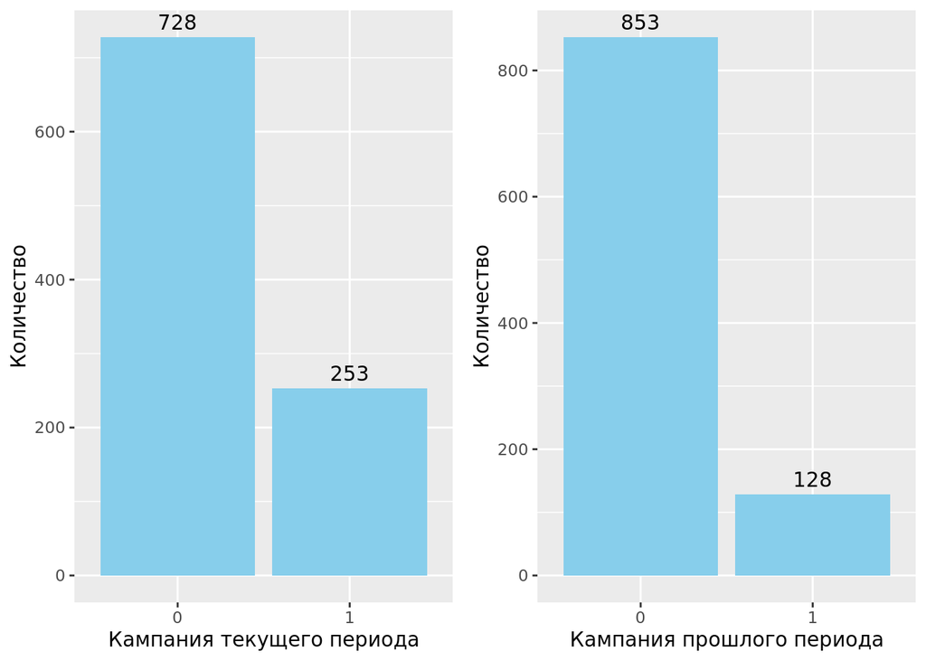

```r
plot2 <- ggplot(marketing_clear, aes(x = AcceptedCmp, label=..count..), label = AcceptedCmp) +
  geom_bar(fill = "skyblue") +
  ylab("Количество") +
  xlab("Кампания прошлого периода") +
  geom_text(stat='count', aes(label=..count..), vjust=-0.5)
grid.arrange(plot1, plot2, ncol=2)
```

**Вопрос 2: Верно ли, что более обечпеченные клиенты чаще оставляют жалобы?**

Для того, чтобы понять степень влияния экономических факторов клиентов на их оценку сервиса компании, нам необходимо исследовать взаимосвязь между доходом домохозяйств и жалобами, которые они оставляют. Так мы сможем определить, какую часть целевой аудитории компания может потерять из-за недостаточно хорошего сервиса, а какая часть целевой аудитории будет основой для дальнейших кампаний. Поскольку заработная плата - не категориальная переменная, а наличие или отсутствие жалоб - категориальная, то уместно будет использовать t-test для анализа.

```r
# код для ответа на вопрос
# вы можете добавлять столько чанков с кодом, сколько вам необходимо, разделяя их текстом с пояснениями
marketing$Complain = as.factor(marketing$Complain)
marketing_clear1 = marketing[complete.cases(marketing$Income), ]
t.test(Income ~ Complain, data = marketing_clear1)
```

```
##
##  Welch Two Sample t-test
##
## data:  Income by Complain
## t = 0.62463, df = 12.475, p-value = 0.5435
## alternative hypothesis: true difference in means between group 0 and group 1 is not equal to 0
## 95 percent confidence interval:
##  -8648.509 15641.436
## sample estimates:
## mean in group 0 mean in group 1
##        53016.62        49520.15
```

**Выводы:** как можно увидеть из результатов, p-value выходит далеко за допустимые значения, что означает, что нулевая гипотеза остается более релевантным объяснением - между доходом и склонностью к жалобам статистически значимой связи нет, что означает, что целевая аудитория не представляется какой-то одной группой доходов. Следовательно, доход не влияет на склонность к жалобам от потребителей.

### Предсказание отклика на кампанию

0. Проверка допустимости переменных

Поскольку в ходе анализа мы смогли обнаружить лишь одну переменную, которая имеет статистически значимую связь с параметром Response, предлагаю также проанализировать еще две переменные – это Recency и NumStorePurchases, чтобы обосновать их допустимость для включения в дерево решений. Как видно из т-тестов, оба эти параметра имеют статистически значимую связь с переменной, отвечающей за отклик клиента, (p-value < 0.05), что позволяет нам включить эти переменные в дерево.

```r
t.test(Recency ~ Response, data = marketing)
```

```
##
##  Welch Two Sample t-test
##
## data:  Recency by Response
## t = 9.605, df = 589.95, p-value < 2.2e-16
## alternative hypothesis: true difference in means between group 0 and group 1 is not equal to 0
## 95 percent confidence interval:
##  13.48316 20.41437
## sample estimates:
## mean in group 0 mean in group 1
##        52.33200        35.38323
```

```r
t.test(NumStorePurchases ~ Response, data = marketing)
```

```
##
##  Welch Two Sample t-test
##
## data:  NumStorePurchases by Response
## t = -2.2165, df = 599.11, p-value = 0.02703
## alternative hypothesis: true difference in means between group 0 and group 1 is not equal to 0
## 95 percent confidence interval:
##  -0.82572159 -0.04989518
## sample estimates:
## mean in group 0 mean in group 1
##        5.658000        6.095808
```

1. Построение дерева

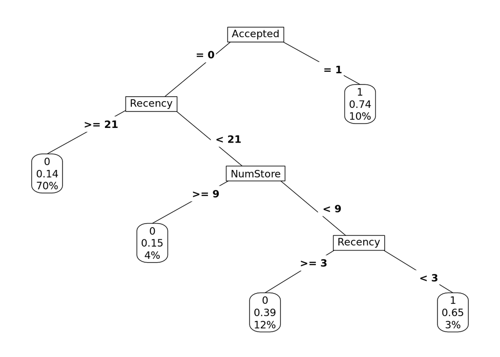

```r
library(rpart)
library(rpart.plot)
library(dplyr)
set.seed(1234)
marketing$Response = as.factor(marketing$Response)
train = sample_frac(marketing, 0.75)

tree <- rpart(Response ~ AcceptedCmp + Recency + NumStorePurchases , method = "class", data = train)
prp(tree, extra = 106, type = 5)
```

```r
?rpart.predict

head(predict(tree))
```

```
##           0         1
## 1 0.8571429 0.1428571
## 2 0.2571429 0.7428571
## 3 0.8571429 0.1428571
## 4 0.8571429 0.1428571
## 5 0.8571429 0.1428571
## 6 0.8571429 0.1428571
```

```r
prediction = predict(tree, type = "class")
```

2. Проверка на переобученность

```r
set.seed(1234)

tree.train = marketing %>% dplyr::sample_frac(.8)
tree.test = dplyr::anti_join(marketing, tree.train)
tree1 <- rpart(Response ~ AcceptedCmp + Recency + NumStorePurchases , method = "class", data = tree.train)


marketing.pred <- predict(tree1, tree.test, type = "class")
head(marketing.pred)
```

```
## 1 2 3 4 5 6
## 0 0 1 0 0 0
## Levels: 0 1
```

```r
t = table(tree.test$Response, marketing.pred)
(t[1,1]+t[2,2])/sum(t)
```

```
## [1] 0.7715356
```

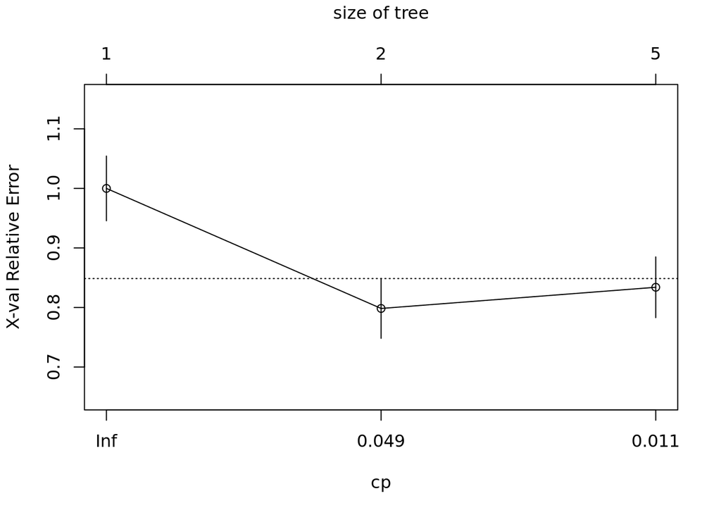

```r
plotcp(tree)
```

3. Оптимизация дерева

```r
set.seed(1234)
printcp(tree)
```

```
##
## Classification tree:
## rpart(formula = Response ~ AcceptedCmp + Recency + NumStorePurchases,
##     data = train, method = "class")
##
## Variables actually used in tree construction:
## [1] AcceptedCmp       NumStorePurchases Recency
##
## Root node error: 253/1000 = 0.253
##
## n= 1000
##
##         CP nsplit rel error  xerror     xstd
## 1 0.201581      0   1.00000 1.00000 0.054338
## 2 0.011858      1   0.79842 0.79842 0.050183
## 3 0.010000      4   0.76285 0.83399 0.050999
```

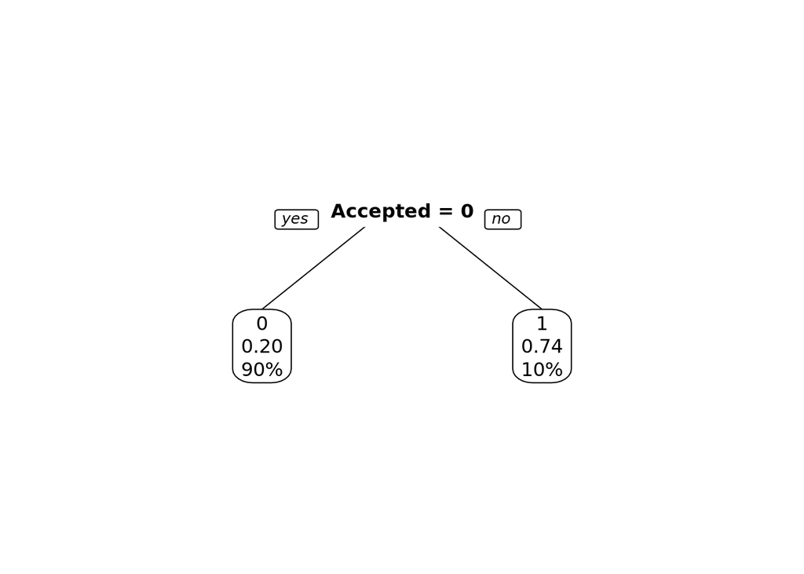

```r
pruned_tree <- prune(tree, cp = tree$cptable[which.min(tree$cptable[,"xerror"]),"CP"])
prp(pruned_tree, extra = 106)
```

**Полученные правила:** как было ожидаемо, наиболее важной переменной, детерминирующей поведение потребителя, является его поведение в прошлом. Если клиент уже откликался на кампанию, то есть больше вероятность того, что он откликнется на нее вновь. Если же клиент на кампанию не откликался, то если прошло больше 3-х недель со дня последней покупки, клиент с меньшей вероятностью примет участие в кампании. Если же прошло менее трех недель и при этом количество покупок в магазине больше или равно 9, то клиент не будет заинтересован в кампании. Если же число покупок менее девяти, причем какие-то из них были сделаны не ранее трех дней до этого, то клиент примет участие в кампании. Такие правила мы можем получить, если воспользуемся расширенной версией дерева. Если же рассматривать оптимизированную версию, то мы убедимся, что деление клиентов на тех, кто уже участвовал в кампаниях и тех, кто от них отказывался, является определяющим фактором. Лишь по нему уже будет можно предсказать поведение потребителя. Точность модели составляет 77%.

## Общие выводы

В ходе проделанной работы мы получили ряд релевантных выводов:

1. Действительно, люди, принявшие предложение об участии в кампаниях прошлых периодов, оказываются более склонными к участию в кампаниях текущих периодов: это мы смогли проследить посредством статистических тестов и графического представления данных
2. Как выяснилось, материальные факторы не влияют на склонность клиентов к жалобам, следовательно, эта характеристика никак не объясняет структуру целевой аудитории
3. Для предсказания отклика потребителей мы взяли только те параметры, которые доказали свою статистическую значимость по отношению к переменной Response. В ходе исследования было обнаружено, что при оптимизации дерева решений все сводится к единственному параметру – поведению потребителя в прошлую кампанию. Можно сделать вывод, что этот параметр действительно является главным для предсказания поведения клиентов.